# US Name

Model estimate Estimate internal finance and pollution emission firm level

# Description

None

# Metadata

- Key: 488_Financial_dependency_pollution
- Epic: Models
- US: Evaluate econometrics model
- Task tag: #internal-finance, #training-Financial-dependency-pollution
- Analytics reports: # Input ## Table/file **Name**
- asif_financial_ratio_baseline_firm
- china_firm_pollution_data **Github**
- https://github.com/thomaspernet/Financial_dependency_pollution/blob/master/02_data_analysis/01_model_train_evaluate/00_estimate_fin_ratio/08_firm_level_estimation_pollution.md

# Load tables

Since we load the data as a Pandas DataFrame, we want to pass the `dtypes`. We load the schema from Glue to guess the types

- 1=state -> 110 141 143 151
- 2=collective -> 120 130 142 149
- 3=private -171 172 173 174 190
- 4=foreign- 210 220 230 240
- 5=Hong Kong, Macau and Taiwan (4 and 5 can be combined into a single "foreign" category - 310 320 330 340

|  | year | geocode4_corr | cic_adj | ind2 | innovation_index | innovation_index_1 | innovation_index_2 |
| --- | --- | --- | --- | --- | --- | --- | --- |
| 0 | 2009 | 4110 | 933 | 93 | 0.000000 | 0.000000 | 0.000000 |
| 1 | 2009 | 4110 | 1099 | 10 | 0.000000 | 0.000000 | 0.000000 |
| 2 | 2009 | 4110 | 1362 | 13 | 0.003356 | 0.003356 | 0.003356 |
| 3 | 2009 | 4110 | 1372 | 13 | 0.000000 | 0.000000 | 0.000000 |
| 4 | 2009 | 4110 | 1421 | 14 | 0.000000 | 0.000000 | 0.000000 |

|  | year | geocode4_corr | cic_adj | ind2 | innovation_index | innovation_index_1 | innovation_index_2 |
| --- | --- | --- | --- | --- | --- | --- | --- |
| count | 3.089920e+06 | 3.089920e+06 | 3.089920e+06 | 3.089920e+06 | 3.089920e+06 | 3.089920e+06 | 3.089920e+06 |
| mean | 2.008500e+03 | 3.781525e+03 | 2.831150e+03 | 3.247206e+01 | 8.927189e-03 | 8.927189e-03 | 8.927189e-03 |
| std | 4.609773e+00 | 1.390503e+03 | 1.455063e+03 | 1.589606e+01 | 1.753013e-01 | 1.753013e-01 | 1.753013e-01 |
| min | 2.001000e+03 | 1.101000e+03 | 1.110000e+02 | 1.000000e+01 | 0.000000e+00 | 0.000000e+00 | 0.000000e+00 |
| 25% | 2.004750e+03 | 3.203750e+03 | 1.777500e+03 | 2.200000e+01 | 0.000000e+00 | 0.000000e+00 | 0.000000e+00 |
| 50% | 2.008500e+03 | 3.714500e+03 | 3.045000e+03 | 3.200000e+01 | 0.000000e+00 | 0.000000e+00 | 0.000000e+00 |
| 75% | 2.012250e+03 | 4.505250e+03 | 3.601750e+03 | 3.800000e+01 | 4.139512e-04 | 4.139512e-04 | 4.139512e-04 |
| max | 2.016000e+03 | 6.502000e+03 | 8.099000e+03 | 9.300000e+01 | 5.673225e+01 | 5.673225e+01 | 5.673225e+01 |

|  | year | province_en | credit_supply_long_term | credit_supply_short_term |
| --- | --- | --- | --- | --- |
| 0 | 1997 | Heilongjiang | 0.13133 | 0.73496 |
| 1 | 1998 | Heilongjiang | 0.14629 | 0.73581 |
| 2 | 1999 | Heilongjiang | 0.16912 | 0.85715 |
| 3 | 2000 | Heilongjiang | 0.19416 | 0.63840 |
| 4 | 2001 | Heilongjiang | 0.23311 | 0.68220 |

```
(633, 11)
```

INFO: Ran model with model id = None

INFO: Ran model with model id = None

|  | extra_code | geocode4_corr | province_en |
| --- | --- | --- | --- |
| 0 | 1100 | 1101 | Beijing |
| 1 | 1101 | 1101 | Beijing |
| 2 | 1102 | 1101 | Beijing |
| 3 | 1200 | 1201 | Tianjin |
| 4 | 1201 | 1201 | Tianjin |

|  | id | certcode | bank_type_adj | bank_type_1 | bank_type | bank_type_details | unknown_code | fullname | registration_type | bank_full_name | citycode | bank_code | year | status | bank_name | Similarity | geocode4_corr | province_en |
| --- | --- | --- | --- | --- | --- | --- | --- | --- | --- | --- | --- | --- | --- | --- | --- | --- | --- | --- |
| 0 | 230500 | B0018S361040060 | SOB | B | 中国邮政储蓄银行 | S | 0060 | 中国邮政储蓄银行股份有限公司兴平市金城路支行 | 有限公司 | 中国邮政储蓄银行股份 | 6104 | B0018S3 | 2012 | no CCB | 中国邮政储蓄银行 | 0.888889 | 6104 | Shaanxi |
| 1 | 230478 | B0018S361040001 | SOB | B | 中国邮政储蓄银行 | S | 0001 | 中国邮政储蓄银行股份有限公司咸阳市人民路支行 | 有限公司 | 中国邮政储蓄银行股份 | 6104 | B0018S3 | 2008 | no CCB | 中国邮政储蓄银行 | 0.888889 | 6104 | Shaanxi |
| 2 | 230451 | B0018S361040027 | SOB | B | 中国邮政储蓄银行 | S | 0027 | 中国邮政储蓄银行股份有限公司咸阳市沣西支行 | 有限公司 | 中国邮政储蓄银行股份 | 6104 | B0018S3 | 2008 | no CCB | 中国邮政储蓄银行 | 0.888889 | 6104 | Shaanxi |
| 3 | 231146 | B0018S361040077 | SOB | B | 中国邮政储蓄银行 | S | 0077 | 中国邮政储蓄银行股份有限公司杨凌区康乐路支行 | 有限公司 | 中国邮政储蓄银行股份 | 6104 | B0018S3 | 2008 | no CCB | 中国邮政储蓄银行 | 0.888889 | 6104 | Shaanxi |
| 4 | 230413 | B0018S361040046 | SOB | B | 中国邮政储蓄银行 | S | 0046 | 中国邮政储蓄银行股份有限公司礼泉县市政街支行 | 有限公司 | 中国邮政储蓄银行股份 | 6104 | B0018S3 | 2008 | no CCB | 中国邮政储蓄银行 | 0.888889 | 6104 | Shaanxi |

```
(21525, 6)
```

```
(21525, 4)
```

```
(14951, 5)
```

```
(21525, 26)
```

|  | year | geocode4_corr | count_ccb | lag_count_ccb | count_no_ccb | lag_count_no_ccb | active_ccb | lag_active_ccb | active_no_ccb | lag_active_no_ccb | share_count_ccb | lag_share_count_ccb | share_active_ccb | lag_share_active_ccb | hhi_branches | lag_hhi_branches | hhi_branches_name | lag_hhi_branches_name | count_false | lag_count_false | count_true | lag_count_true | concentration | lag_concentration |
| --- | --- | --- | --- | --- | --- | --- | --- | --- | --- | --- | --- | --- | --- | --- | --- | --- | --- | --- | --- | --- | --- | --- | --- | --- |
| 21520 | 2022 | 6403 | 10.0 | 10.0 | 66.0 | 66.0 | 1.0 | 1.0 | 6.0 | 6.0 | 0.131579 | 0.131579 | 0.142857 | 0.142857 | 0.815789 | 0.815789 | 0.857143 | 0.857143 | NaN | NaN | NaN | NaN | 0.223144 | 0.223144 |
| 21521 | 2022 | 6404 | 5.0 | 5.0 | 39.0 | 39.0 | 2.0 | 2.0 | 5.0 | 5.0 | 0.113636 | 0.113636 | 0.285714 | 0.285714 | 0.735537 | 0.735537 | 0.857143 | 0.857143 | NaN | NaN | NaN | NaN | 0.223144 | 0.223144 |
| 21522 | 2022 | 6405 | 7.0 | 7.0 | 34.0 | 34.0 | 1.0 | 1.0 | 6.0 | 6.0 | 0.170732 | 0.170732 | 0.142857 | 0.142857 | 0.814991 | 0.814991 | 0.857143 | 0.857143 | NaN | NaN | NaN | NaN | 0.275412 | 0.275412 |
| 21523 | 2022 | 6501 | 97.0 | 95.0 | 345.0 | 345.0 | 5.0 | 5.0 | 8.0 | 8.0 | 0.219457 | 0.215909 | 0.384615 | 0.384615 | 0.847126 | 0.847345 | 0.923077 | 0.923077 | NaN | NaN | NaN | NaN | 0.297252 | 0.295041 |
| 21524 | 2022 | 6502 | 14.0 | 14.0 | 52.0 | 52.0 | 2.0 | 2.0 | 6.0 | 6.0 | 0.212121 | 0.212121 | 0.250000 | 0.250000 | 0.832874 | 0.832874 | 0.875000 | 0.875000 | NaN | NaN | NaN | NaN | 0.287682 | 0.287682 |

```
(121231, 191)
```

```
1    100775
2     20456
Name: change_status_soe, dtype: int64
```

```
1    83576
2    37655
Name: change_status_foreign, dtype: int64
```

```
-2    80462
-1    40769
Name: flag_discontinuous, dtype: int64
```

```
8    21238
7    18221
6    16283
5    15324
4    13577
3    10687
2     9989
1     7759
0     6569
9     1584
Name: missing_years, dtype: int64
```

[output not shown]

40769 rows × 191 columns

## Schema Latex table

To rename a variable, please use the following template:

```
{
    'old':'XX',
    'new':'XX_1'
    }
```

if you need to pass a latex format with `\`, you need to duplicate it for instance, `\text` becomes `\text:

```
{
    'old':'working\_capital\_i',
    'new':'\\text{working capital}_i'
    }
```

Then add it to the key `to_rename`

```
 Hlavac, Marek (2018). stargazer: Well-Formatted Regression and Summary Statistics Tables.
 R package version 5.2.2. https://CRAN.R-project.org/package=stargazer
```

# Main results

### Summary:

**Baseline Observations**:

- Firms with a higher proportion of tangible assets tend to produce more SO2 emissions, likely due to more intensive manufacturing activities.
- Efficient and financially healthy firms, especially older ones, tend to emit less SO2. This might be attributed to the adoption of cleaner technologies and better processes.
- As expected, firms with SO2 reducing equipment have fewer emissions.
- State-owned enterprises emit more SO2 than their private counterparts.

**Heterogeneity Observations**:

- Cash-rich firms are proactive about reducing emissions when facing industry-wide financial constraints or localized banking biases.
- Firms with stronger cashflows in cities with SO2 reduction policies (TCZ cities) or in growth-focused zones (SPZ cities) are more proactive in reducing emissions.

**Mechanism Observations**:

- Firms with higher cashflows tend to invest less in tangible assets and more in R&D, emphasizing a move towards innovation over traditional asset acquisition.
- A financial shift is observed where liquidity-driven firms prioritize long-term growth and efficiency, especially when facing challenges in accessing traditional bank loans.

**Investment in Pollution Abatement**:

- Firms with ample liquidity invest more in pollution control technologies, leading to a direct increase in their capacity to reduce pollution.
- Bigger firms, both in terms of assets and age, demonstrate a better capability to manage pollution, whereas firms with larger employee counts seem to face challenges in efficient pollution control.
- State-owned enterprises lag behind in pollution abatement capacities compared to private firms.

In essence, the study underscores the integral role of a firm's financial health, particularly cashflows, in its environmental responsibilities and practices. The balance between financial constraints and proactive investments in cleaner technologies and processes is evident. Additionally, the nature, size, age, and ownership of a firm play nuanced roles in determining its environmental responsiveness, especially in the context of SO2 emissions and controls.

### Baseline

1. **Asset Tangibility**: A positive relationship with SO2 emissions suggests that firms with a higher proportion of tangible assets tend to emit more SO2. This might be because companies with more physical assets (like factories) are more involved in manufacturing, which can lead to more emissions.
2. **Total Factor Productivity (tfp_op)**: A negative coefficient indicates that firms with higher productivity emit less SO2. This is interesting because it suggests that more efficient firms might be using cleaner technologies or better processes, leading to lower emissions.
3. **Cashflow to Asset**: A negative coefficient for this variable suggests that firms with more internal financing capabilities (as measured by their cashflows relative to their assets) emit less SO2. This could be because these firms might be more capable of investing in cleaner technologies.
4. **Current Ratio**: The negative relationship with SO2 emissions implies that firms with more current assets relative to their current liabilities might be less pollutive. This might be an indication of the financial health of a company, and financially healthier companies might be more environmentally responsible.
5. **Coverage Ratio**: The negative coefficient suggests that firms with higher abilities to cover their interest expenses emit less SO2, possibly due to better financial health and the capability to adopt cleaner technologies.
6. **Liabilities to Asset**: The mixed signs across different models suggest the relationship between the leverage of a firm and its emissions is not straightforward and needs further investigation.
7. **Sales to Asset**: The strong negative relationship suggests that more efficient firms in terms of sales per unit of asset tend to emit less SO2. This could again be an indication of the efficiency and possible adoption of cleaner technologies.
8. **Age Square (age_sqr)**: The negative coefficient indicates that older firms, possibly more established, emit less SO2. This could be due to older firms having more experience and resources to invest in cleaner technologies.
9. **Dummy for SO2 Equipment (dummy_dso2_equip)**: The negative sign suggests that firms that have invested in SO2 reducing equipment emit less SO2, as expected.
10. **State-Owned Enterprises (SOESOE)**: The positive relationship indicates that state-owned enterprises emit more SO2 compared to their counterparts.

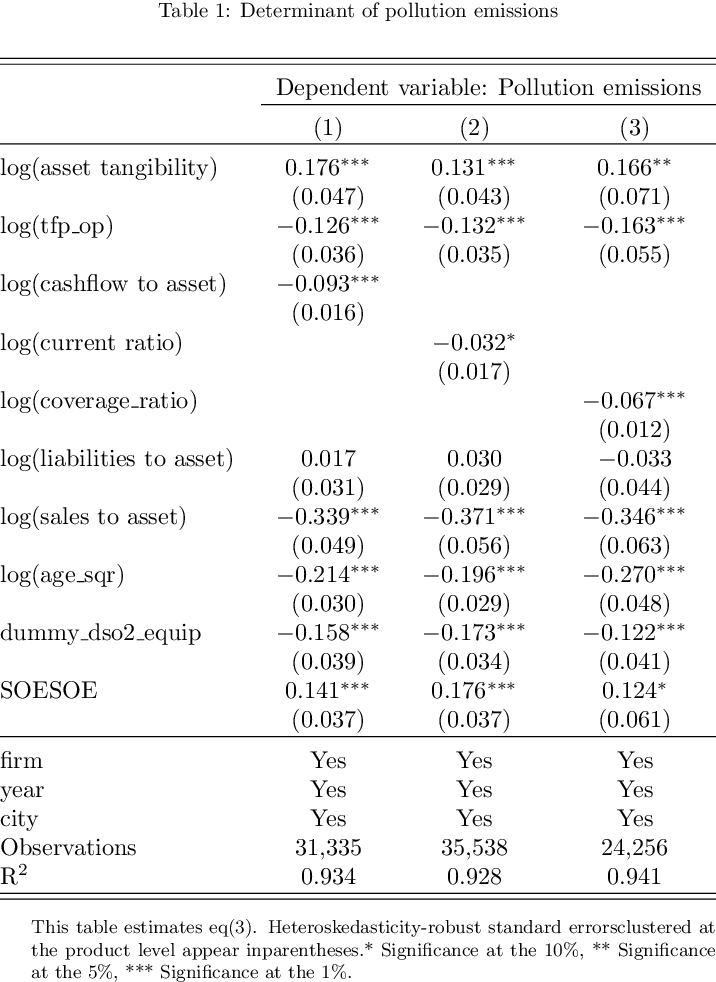

## Heterogeneity effect

- heterogeneity by sector and by city

### Heterogeinety

1. **Cashflow × financial_dep_china1:** A higher `financial_dep_china1` value indicates that the industry is more financially constrained, meaning it's difficult for firms to borrow money. The negative coefficient for this interaction indicates that in industries with tougher borrowing conditions, firms with higher cashflows are more inclined to reduce their SO2 emissions compared to those in less constrained industries. These firms may use their stronger cashflow to invest in cleaner technologies, production processes, or other measures that decrease their environmental footprint. This could be a way to mitigate potential regulatory risks, reduce future liabilities, or to proactively adopt sustainable practices given their limited access to external financing.
2. **Cashflow × concentration:** The negative coefficient of this interaction suggests that in cities where the big 4 banks dominate (and where these banks are biased towards lending to state-owned enterprises), private firms with more substantial cashflows are more proactive in reducing their emissions than in cities with a less concentrated banking sector. This implies that in areas where there's an implicit banking bias against private entities, such entities use their cashflows more efficiently to invest in emission-reducing measures. This could be a strategy for these private firms to demonstrate environmental responsibility, making them potentially more attractive for alternate financing, partnerships, or to appeal to a more environmentally-conscious customer base.
3. **Cashflow × tcz:** Firms in cities with a policy to reduce SO2 emissions (i.e., TCZ cities) tend to reduce their SO2 emissions more as their cashflow relative to assets increases. This suggests that cash-rich firms in environmentally conscious cities are more proactive or efficient in leveraging their cashflows to invest in reducing emissions. This might be because these firms face greater regulatory scrutiny, have more public pressure to be environmentally responsible, or see economic benefits in compliance due to potential incentives provided by such cities
4. **Cashflow × spz:** The negative coefficient indicates that in SPZ cities, which are focused on economic growth, firms with higher cashflows tend to reduce their SO2 emissions more than those with weaker cashflows. This can be seen as evidence that even in growth-oriented regions, companies with more substantial financial strength (in terms of cashflow) prioritize or at least do not neglect environmental considerations, possibly as a strategy to ensure long-term sustainable growth.

In essence, the interactions with cashflow suggest that firms with better cash positions are proactive about reducing emissions, especially when faced with industry-wide financial constraints or localized banking biases. Their stronger cash position allows them to navigate and adapt to both financial and environmental challenges more effectively.

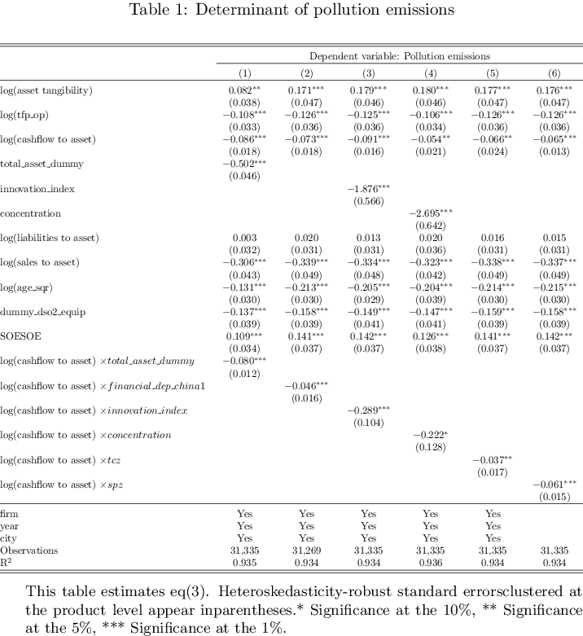

### Transmission channel

Faire avec taille

Regarder l'hétérogénéity, SOE/foreign/taille

- Changer de polluants

Est ce que l'accès a la finance interne affecte les emissions.

Une entreprise publique/large est moins sensible a la contrainte de crédit.

### Mechanism

1. **Asset Tangibility**:
   - **Log(cashflow)**: Firms with higher cashflow tend to decrease their investments in tangible assets. This resonates with the understanding that when firms possess ample cash flow, they exhibit greater discretion in investment choices and are not necessitated to invest heavily in tangible assets for the sole purpose of collateralization to secure bank loans. This dynamic is particularly accentuated in environments like China where tangible assets are frequently leveraged as collateral for loan procurements.
2. **R&D (Research and Development)**:
   - **Log(cashflow)**: An upsurge in cashflow is associated with increased investments in R&D. This underscores the perspective that banks often exhibit reservations toward financing innovative endeavors due to the intangible nature of intellectual property, which cannot be readily collateralized like tangible assets. Hence, firms flush with cash are inclined to self-finance their innovative ventures, leading to elevated R&D investments.
3. **TFP (Total Factor Productivity)**:
   - **Log(cashflow)**: Enhanced cashflow correlates with a surge in a firm's total factor productivity. This can be attributed to the possibility that firms with substantial liquidity can channel investments into state-of-the-art technologies or processes, and effectively allocate resources towards innovative or avenues promising growth.

From the outlined mechanisms:

- Financial constraints, through by cash flow, wield significant influence over a firm's investment strategies. With augmented cash flow, firms, especially private entities that might be marginalized by predominant banks, exercise autonomy in investment decisions. Rather than allocating resources to tangible assets, predominantly viewed as a vehicle to procure loans, there's a palpable shift towards innovation (R&D) — an avenue that holds the promise of sustained growth and heightened efficiency.
- This trend is emblematic of a broader economic shift where, sufforing by financial constraints, firms prioritize long-term growth, innovation, and efficiency over transient needs or the acquisition of external finance. Within a framework where traditional bank loans could be elusive for a subset of firms, especially against a landscape of credit concentration and preferential lending patterns favoring SOEs, internal cash reserves assume paramount importance in guiding investment choices.

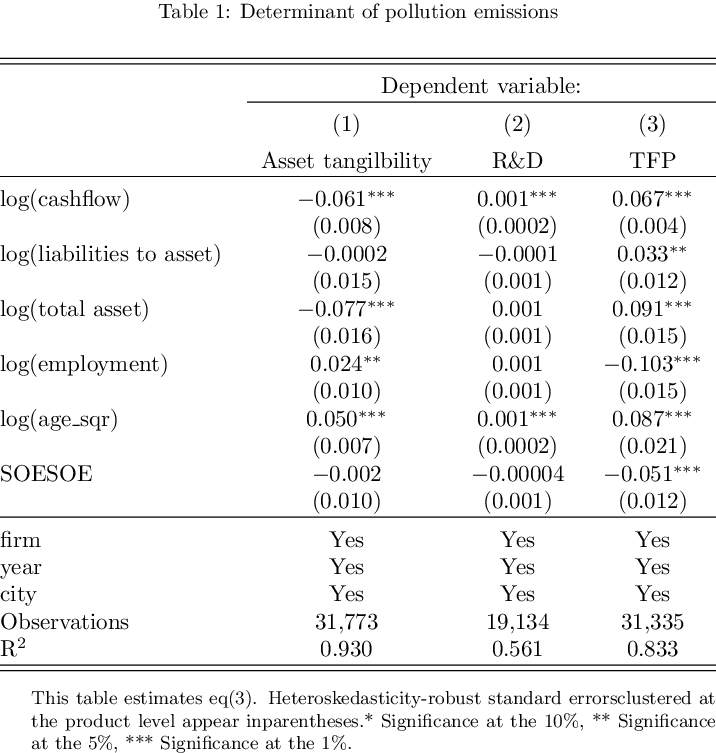

Removal capacity

[output not shown]

### Investment in Pollution Abatement:

1. **Abatement capacity**:
   - **Log(cashflow)**: Firms with a higher cashflow are found to increase their abatement capacity, implying that an increase in liquidity allows firms to invest in technologies and systems that enhance their capacity to reduce pollution. This suggests a proactive response by liquidity-rich firms in environmental stewardship.
2. **SO2 removed**:
   - **Log(cashflow)**: Higher cashflows lead to a significant increase in the amount of SO2 removed. Firms that possess ample liquidity are, evidently, deploying it to enhance their environmental footprint by adopting more efficient pollution abatement technologies.
3. **SO2 removed over yield**:
   - **Log(cashflow)**: Firms with increased cashflow are more effective at removing SO2 for each unit of their output. This emphasizes the efficiency gains that liquidity can bring about in pollution control, further supporting the premise that cash-rich firms are more environmentally efficient per unit of their production.
4. **SO2 removal per hour**:
   - **Log(cashflow)**: An increase in cashflow correlates with more efficient hourly SO2 removal rates. This implies that liquidity not only aids in sheer volume but also in the efficiency of the pollution control mechanisms.

Apart from the effects of cashflow:

- **Log(liabilities to asset)**: Higher liabilities relative to assets lead to an increase in abatement capacity, SO2 removed over yield, and SO2 removal per hour. This may be indicative of firms with higher leverage taking more proactive environmental actions, possibly to project a more responsible image to stakeholders or to meet certain regulatory compliances associated with their liabilities.
- **Log(total asset)**: Larger firms, in terms of total assets, have markedly higher abatement capacities, remove more SO2, have improved SO2 removal efficiency over yield, and remove SO2 more efficiently per hour. This highlights that bigger firms, potentially due to economies of scale and greater resources, are better equipped to invest in and manage pollution control measures.
- **Log(employment)**: Larger firms in terms of employment, conversely, are found to have a reduced abatement capacity and lower SO2 removal efficiency per hour. It might suggest that firms with more employees face challenges in managing and deploying pollution control measures as effectively as asset-rich firms.
- **Log(age_sqr)**: Older firms tend to have a greater abatement capacity, remove more SO2, and display improved efficiency in terms of SO2 removed over yield and per hour. Long-standing firms might possess more established processes and infrastructures to deal with pollution control.
- **SOESOE (State-Owned Enterprises)**: Compared to private entities, state-owned enterprises showcase a decreased abatement capacity and are less efficient in terms of SO2 removal per hour. This could be reflective of differing priorities or operational efficiencies between state-run and private enterprises.

In summary, the results shed light on the pivotal role that liquidity, in the form of cashflow, plays in a firm's environmental endeavors, specifically in the realm of SO2 abatement. It further underscores the nuanced ways in which firm size, leverage, age, and ownership influence environmental responsiveness in the context of SO2 pollution control.

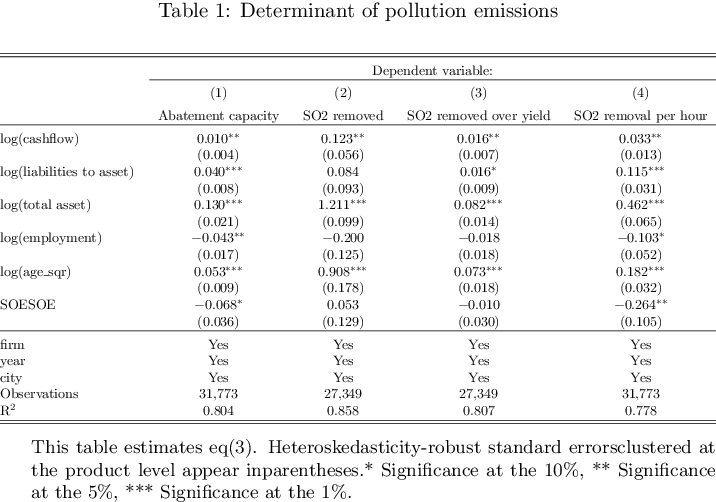